# CSSS 512 HW 3

Chris Hess

May 10, 2018

## Problem 1

### Part a

```r
#process data
house <- read_csv("statehouse.csv") %>%
  filter(GovCycle == 1, #gov cycle needs to be 2010, 2014, 2018...
         HouseTerm == 2) %>% #2 yr house term only
  arrange(State, Year) %>% #arrange by State, then year within States
  group_by(State) %>% #group rows by State for lagging
  mutate(DemHouseShareL1 = lag(DemHouseShare, 1), #use dplyr::lag with properly ordered and grouped tbl
         DemHouseShareL2 = lag(DemHouseShare, 2),
         DemHouseShareL3 = lag(DemHouseShare, 3),
         DemHouseShareL4 = lag(DemHouseShare, 4))
#double check work using dplyr::lag()
#house %>%
#  select(State, Year, DemHouseShare, DemHouseShareL1, DemHouseShareL2, DemHouseShareL3, DemHouseShareL4) %>%
#  View()

#28 states
length(unique(house$State))
```

```
## [1] 28
```

```r
#20 periods
length(unique(house$Year))
```

```
## [1] 20
```

### Part b

Looks like AR(1) processes in most states. Some of the observed time-series look non-stationary given no reversion to a mean over the full length of periods. Other States’ series, however, look like stationarity assumption is less problematic. The nonstationary conclusion is also supported by a fair number `adf.test` and `PP.test` p-values falling outside of the conventional p<.05 threshold, though these are weak tests.

States with clear change over the period show decreashing democratic vote shares over the full set of periods, though there are states like New York which oppose this direction. The IPS tests suggest that we could consider the panel as stationary with individual intercepts and trends (i.e. enough of the panel is stationary with these adjustments is what I glean from the test, at least based on my understanding of what it’s testing for). While region-specific trends are not a perfect solution, we can’t identify a model with case-specific trends so the M2 specification is probably the best we can do for modeling the temporal dynamics enough to achieve stationarity without resorting to an integrated model.

```r
#make some file structure for output
if(!dir.exists("output")){
  dir.create("output")
  dir.create("output/ts")
  dir.create("output/acf")
  dir.create("output/pacf")
}

#empty obj for unit root test results
unitroot.tbl <- NULL

#iterate through states
for(state in unique(house$State)){

  #pull the state's ts
  ts <- house %>%
    filter(State == state) %>%
    pull(DemHouseShare)

  #make it ts class
  ts <- ts(ts, start = 1978, end = 2016, frequency = 1/2)

  #plot the ts
  TS <- autoplot(ts) +
    scale_y_continuous(labels = scales::percent) +
    labs(title = paste0("Democratic House Share for ", house$Statename[house$State == state])) +
    theme_minimal()

  #plot the ACF
  ACF <- ggAcf(ts) +
    labs(title = paste0("ACF for ", house$Statename[house$State == state])) +
    theme_minimal()

  #plot the PACF
  PACF <- ggPacf(ts) +
    labs(title = paste0("PACF for ", house$Statename[house$State == state])) +
    theme_minimal()

  #rum ADF test, parse results to row
  ADF <- tseries::adf.test(ts)
  ADF.row <- data.frame(state = state,
                        test = "ADF",
                        statistic = ADF[['statistic']],
                        parameter = ADF[['parameter']],
                        p.value = ADF[['p.value']],
                        stringsAsFactors = F)

  #run PP test, parse results to row
  PP <- PP.test(ts)
  PP.row <- data.frame(state = state,
                       test = "PP",
                       statistic = PP[['statistic']],
                       parameter = PP[['parameter']],
                       p.value = PP[['p.value']],
                       stringsAsFactors = F)

  #write graphics to pdf
  ggsave(TS, filename = paste0("./output/ts/", state, "_ts.pdf"),
         width = 8, height = 6, dpi = 300)
  ggsave(ACF, filename = paste0("./output/acf/", state, "_acf.pdf"),
         width = 8, height = 6, dpi = 300)
  ggsave(PACF, filename = paste0("./output/pacf/", state, "_pacf.pdf"),
         width = 8, height = 6, dpi = 300)

  #add row to unit root tbl
  unitroot.tbl <- bind_rows(unitroot.tbl, ADF.row, PP.row)
}
#panel unit root test
ts <- with(house, data.frame(split(DemHouseShare, as.character(State))))
purtest(ts, pmax = 4, exo = "intercept", house_p, test = "ips")
```

```
##
##  Im-Pesaran-Shin Unit-Root Test (ex. var.: Individual Intercepts)
##
## data:  ts
## z = -1.0999, p-value = 0.1357
## alternative hypothesis: stationarity
```

```r
purtest(ts, pmax = 4, exo = "trend", house_p, test = "ips")
```

```
##
##  Im-Pesaran-Shin Unit-Root Test (ex. var.: Individual Intercepts
##  and Trend)
##
## data:  ts
## z = -5.6466, p-value = 8.182e-09
## alternative hypothesis: stationarity
```

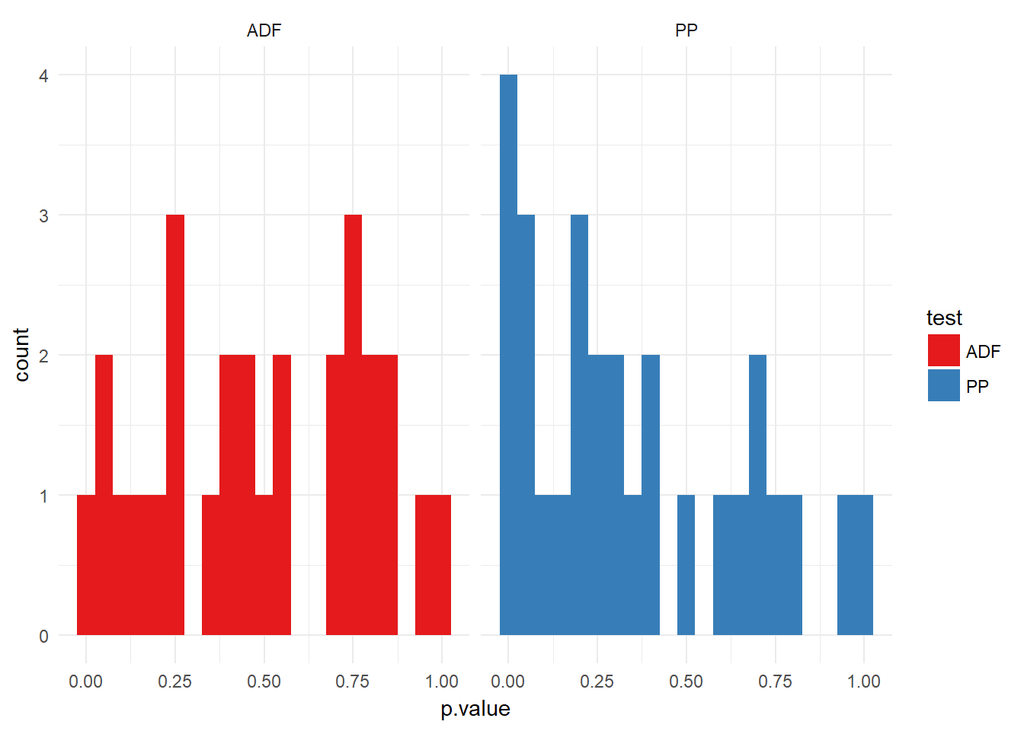

```r
#write unit root tbl to storage
write_csv(unitroot.tbl, "output/unitroot_tests.csv")

#plot unit root p.val dist
ggplot(unitroot.tbl, aes(x = p.value, fill = test)) +
  facet_wrap(~ test) +
  geom_histogram(binwidth = .05) +
  theme_minimal() +
  scale_fill_brewer(palette = "Set1")
```